# Tema 4: condiciones de optimalidad y KKT

## Ejemplo 2: Caso 2 – Una única restricción activa ($g_4$)

- **Condición**: $u_4 > 0$, $u_1 = u_2 = u_3 = 0$ ($g_4 = -y = 0$).
- **Coordenadas**: $y = 0 \implies x = 2.25$.
- **Multiplicador**: $u_4 = -4 < 0$ (candidato a máximo).
- **Factibilidad primal**: $g_1(2.25, 0) = -2.25 \le 0$ (factible). $g_2(2.25, 0) = 2.25 - 6 = -3.75 \le 0$ (factible).
- **Candidato**: $(2.25, 0)^T$.

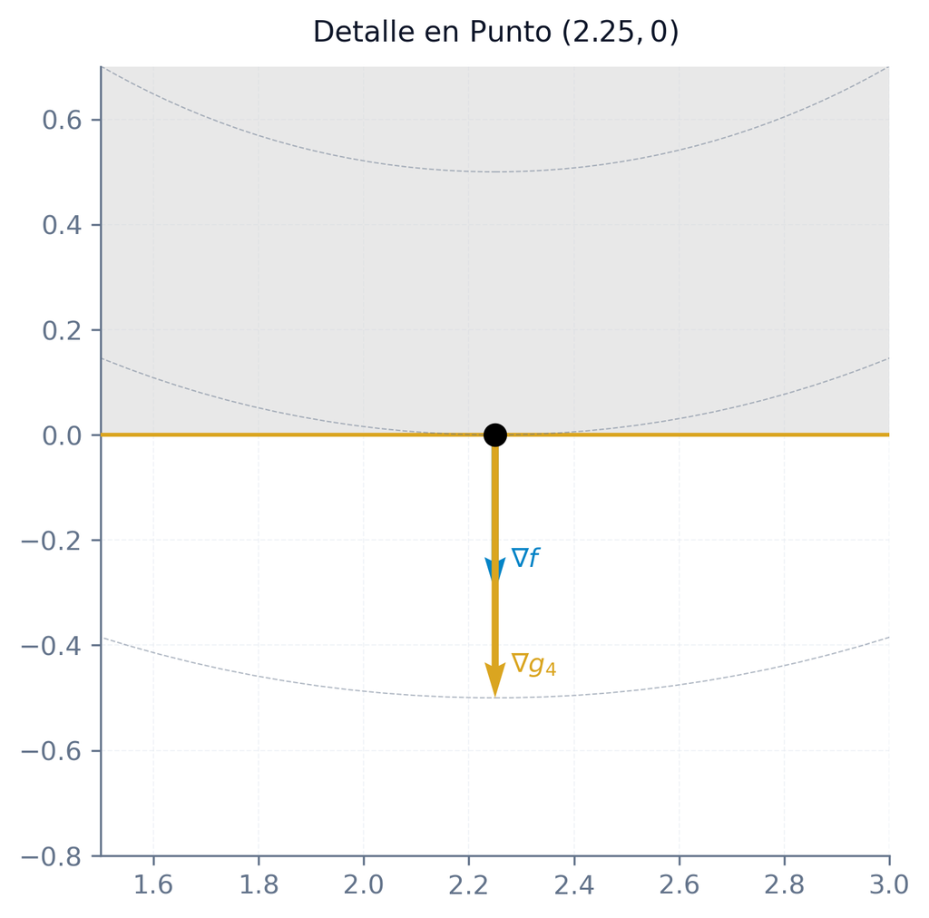

## Ejemplo 2: Caso 3 – Dos restricciones activas ($g_1, g_2$)

- **Condición**: $u_1, u_2 \neq 0, \ u_3=u_4=0$.
- **Intersección**: $x = y^2$ y $x+y=6 \implies y^2+y-6=0 \implies y=2, \ x=4$.
- **Multiplicadores**:
  $$3.5 - u_1 + u_2 = 0$$
  $$4u_1 + u_2 = 0 \implies u_1 = 0.70 > 0, \ u_2 = -2.80 < 0$$
- **Resultado**: Signos opuestos $\implies$ **se descarta** (no es candidato a mínimo ni a máximo).

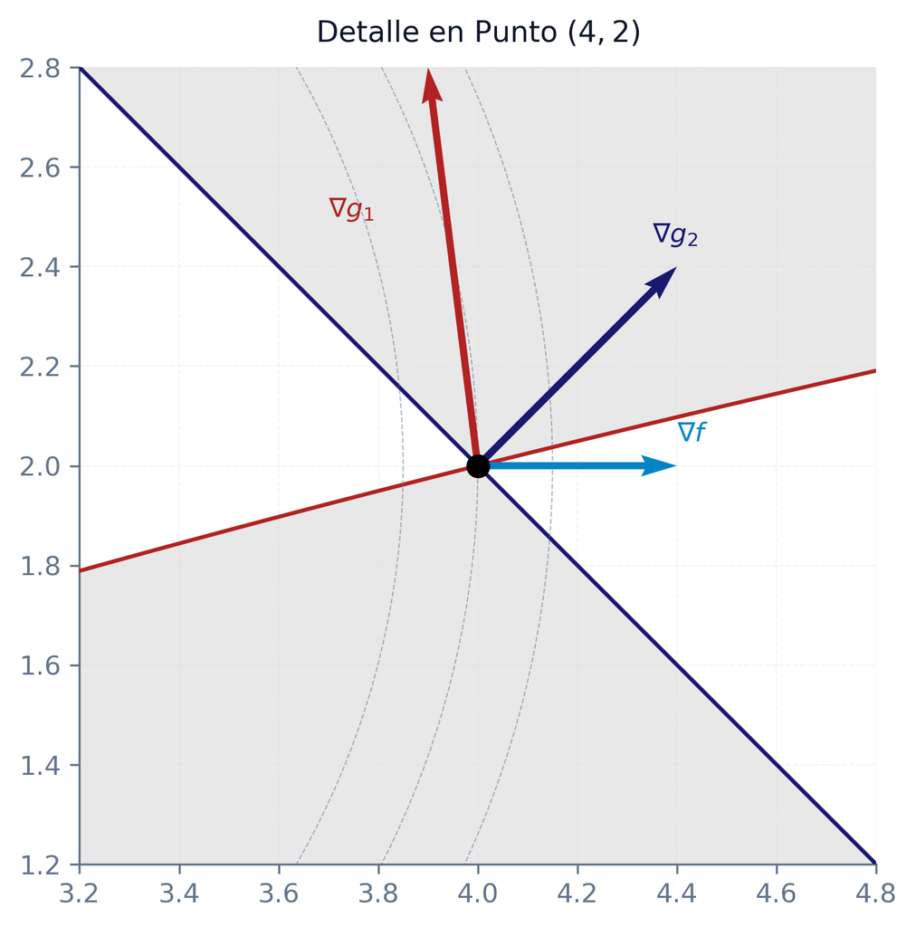

## Ejemplo 2: Caso 3 – Dos restricciones activas ($g_2, g_4$)

- **Condición**: $u_2, u_4 > 0$, $u_1 = u_3 = 0$ ($x+y=6, \ y=0 \implies x=6$).
- **Multiplicadores**: $u_2 = -7.50 < 0$ y $u_4 = -11.50 < 0$ (candidato a máximo).
- **Factibilidad primal**: $g_1(6,0) = -6 \le 0$ (factible).
- **Candidato**: $(6, 0)^T$.

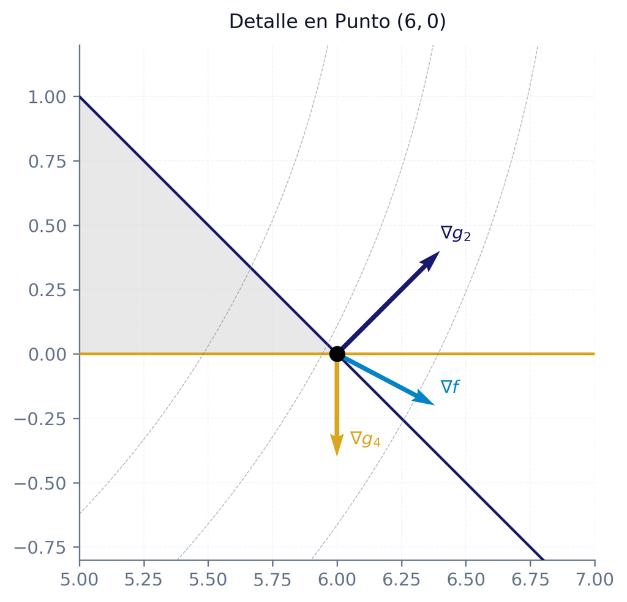

## Ejemplo 2: Caso 3 – Dos restricciones activas ($g_3, g_4$)

- **Condición**: $u_3, u_4 \neq 0, \ u_1=u_2=0 \implies x = 0, \ y = 0$.
- **Multiplicadores**: $u_3 = -4.50 < 0$ y $u_4 = -4.00 < 0$ (candidato a máximo).
- **Fallo de LICQ**: En $(0,0)^T$ la restricción $g_1(0,0)=0$ también es activa. Los gradientes son dependientes.
- **Resultado**: Punto singular Fritz-John con $u_0 = 0$, candidato a máximo local.

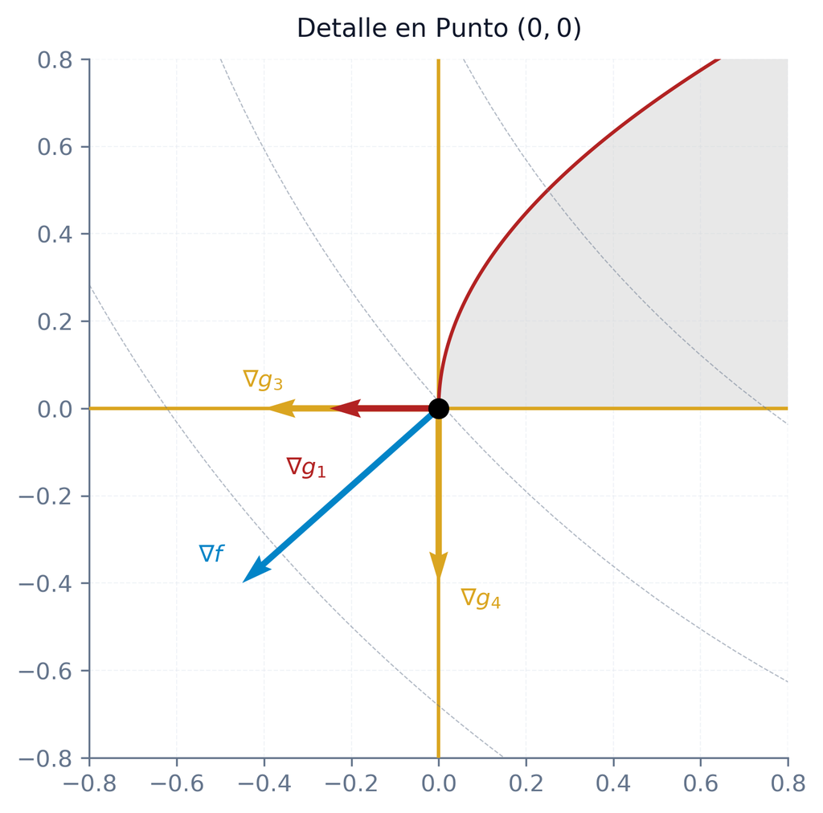

## Ejemplo 2: Conclusión y Comparación

- **Mínimos**: El único candidato KKT es **$(2.40, 1.55)^T$** con $f(2.40, 1.55) \approx 0.22$. Al ser el objetivo estrictamente convexo, es el **mínimo global**.
- **Máximos**: Evaluamos candidatos ($u_i \le 0$):
  - $(2.25, 0)^T \implies f(2.25, 0) = 4.00$
  - $(6, 0)^T \implies f(6, 0) = 18.06$ (**Máximo global**)
  - $(0, 0)^T \implies f(0, 0) = 9.06$ (Singular, máximo local)

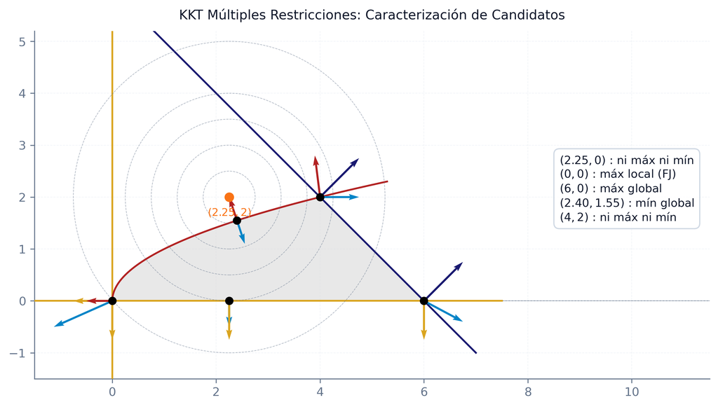

## Ejemplo 3: Restricción circular y lineal (Planteamiento)

- **Problema de estudio**:
  $$\min/\max \quad f(x, y) = 3x - y$$
  $$\text{s.a.} \quad g_1(x, y) = x^2 + y^2 - 1 \le 0$$
  $$g_2(x, y) = -4x - y + 1 \le 0$$
- **Gradientes**: $\nabla f = (3, -1)^T$ $\nabla g_1 = (2x, 2y)^T$ $\nabla g_2 = (-4, -1)^T$
- **Lagrangiana**:
  $$L = 3x - y + u_1(x^2 + y^2 - 1) + u_2(-4x - y + 1)$$

[figure not shown]

## Ejemplo 3: Caso 1 – Inactivas y Caso 2 ($g_1$ activa con $u_1 > 0$)

- **Caso 1 (Inactivas)**: Contradicción $3=0$ y $-1=0$.
- **Caso 2 ($g_1$ activa, $u_2=0$)**: $x = -3/(2u_1)$, $y = 1/(2u_1)$ con $x^2+y^2=1$.
  $$\implies u_1 = \pm\sqrt{10}/2 \approx \pm 1.58$$
- **Si $u_1 \approx 1.58 > 0$ (mínimo)**: $x \approx -0.95$, $y \approx 0.32$.
- **Factibilidad primal**: $g_2(x, y) \approx 4.48 > 0$ (no factible). Se descarta.

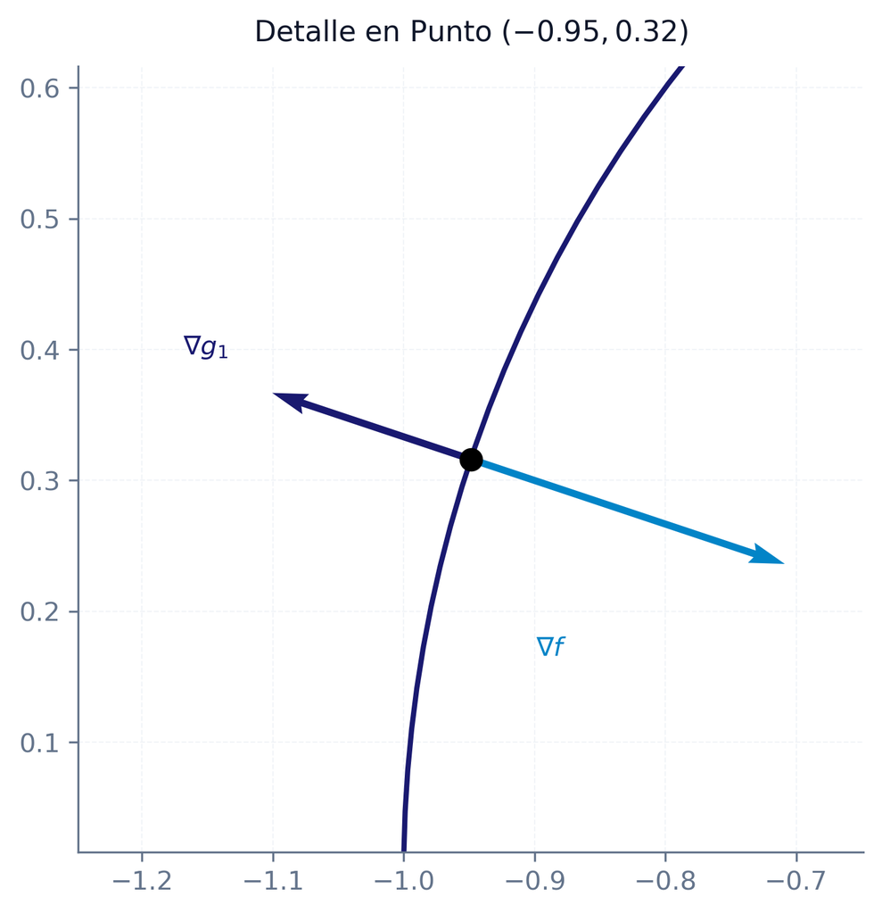

## Ejemplo 3: Caso 2 – Solo $g_1$ activa con $u_1 < 0$

- **Si $u_1 \approx -1.58 < 0$ (máximo)**:
  $$x = \frac{3}{\sqrt{10}} \approx 0.95, \quad y = -\frac{1}{\sqrt{10}} \approx -0.32$$
- **Factibilidad primal**: $g_2(x, y) \approx -2.48 \le 0$ (factible).
- **Candidato a máximo**: $\left(\frac{3}{\sqrt{10}}, -\frac{1}{\sqrt{10}}\right)^T$ con $u = (-\sqrt{10}/2, 0)^T$.
- *Subcaso $g_2$ activa, $u_1=0$*: Contradicción $u_2 = 0.75$ y $u_2 = -1$.

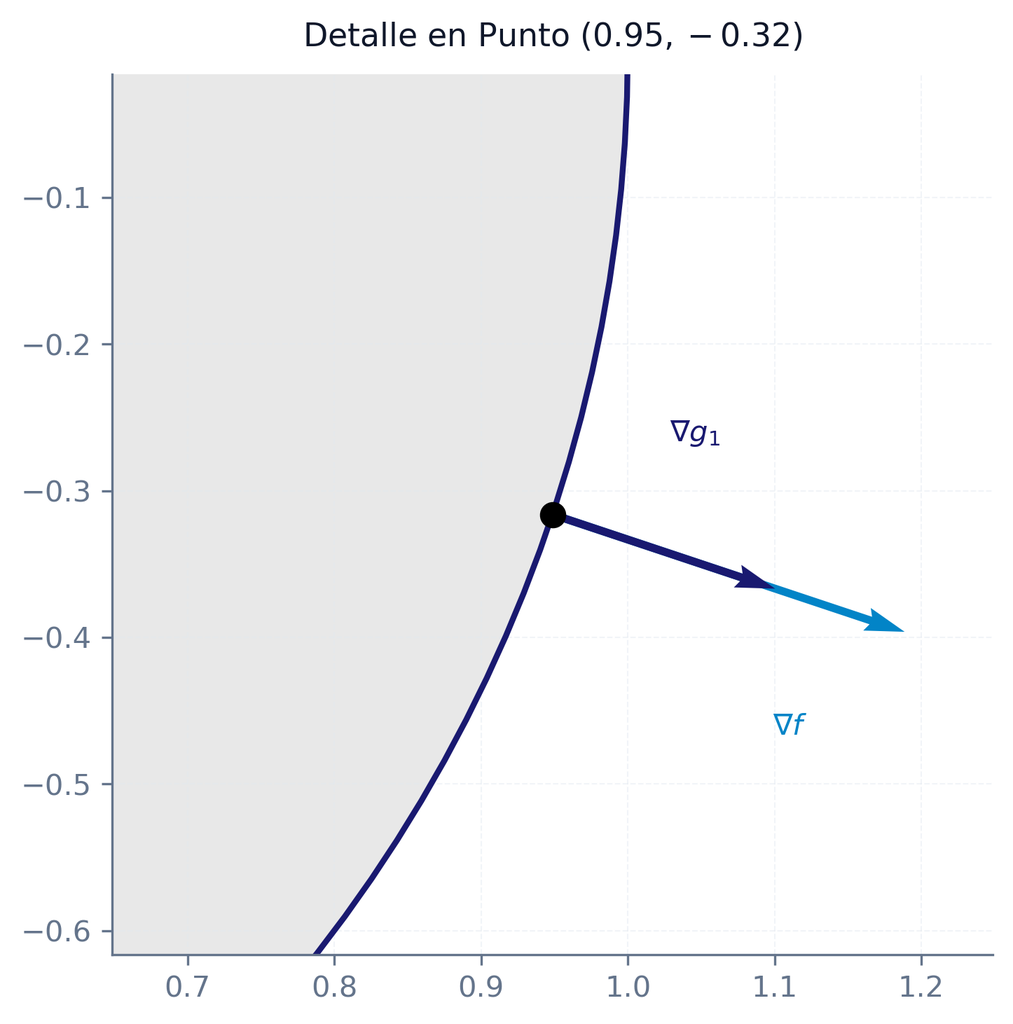

## Ejemplo 3: Caso 3 – Ambas restricciones activas (Intersección)

- **Intersección**: $x^2+y^2=1$ y $-4x-y+1=0 \implies y=1-4x$.
  $$\implies 17x^2-8x=0 \implies x=0 \ \text{ó} \ x=8/17$$
- **Punto $P_1(0,1)^T$**: $3 - 4u_2 = 0 \implies u_2 = 3/4 \ge 0$. $-1 + 2u_1 - u_2 = 0 \implies u_1 = 7/8 \ge 0$.
- **Candidato a mínimo**: $P_1(0,1)^T$ con $u = (7/8, 3/4)^T$.

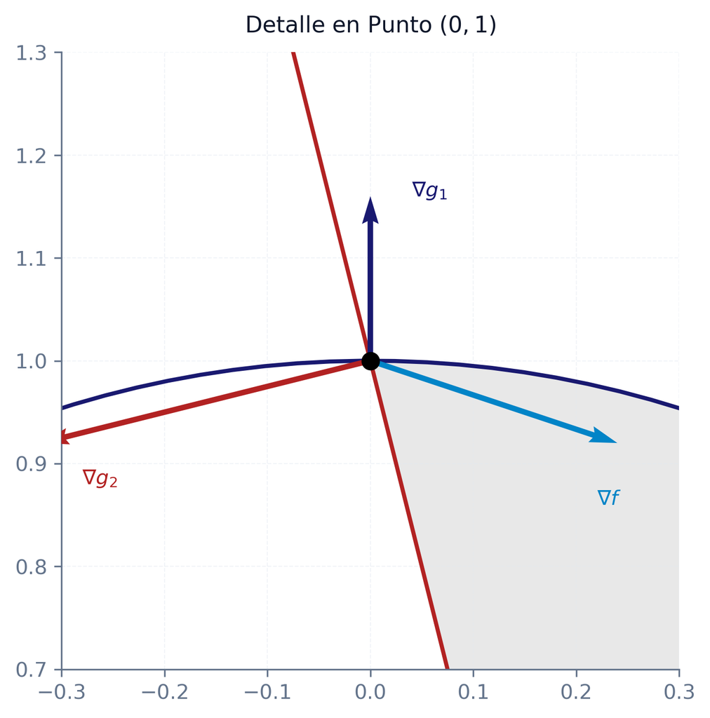

## Ejemplo 3: Caso 3 – Intersección (Punto $(8/17, -15/17)^T$)

- **Punto $P_2(8/17, -15/17)^T$**: $3 + \frac{16}{17}u_1 - 4u_2 = 0$. $-1 - \frac{30}{17}u_1 - u_2 = 0$.
- **Solución**: $u_1 = -7/8 < 0$ y $u_2 = 37/68 > 0$.
- **Conclusión**: Signos opuestos $\implies$ se descarta. No es punto KKT de primer orden.

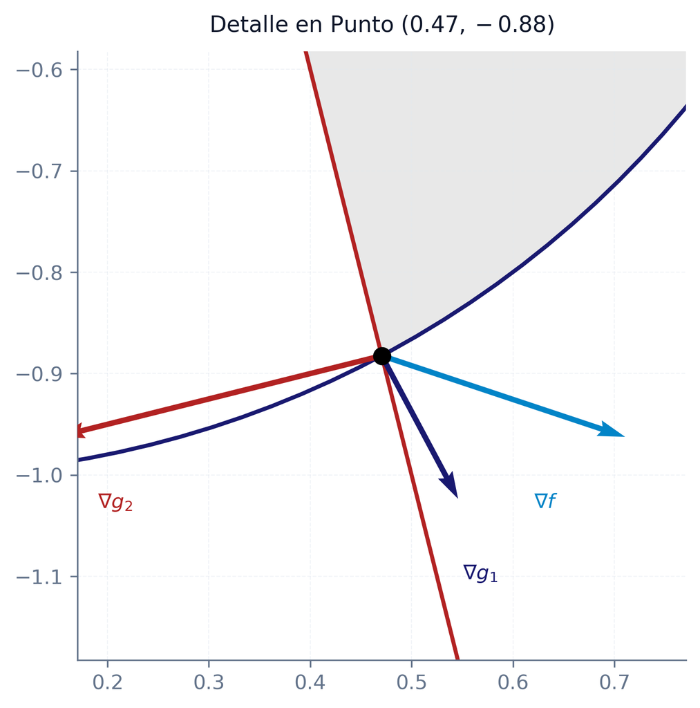

## Ejemplo 3: Conclusión y Caracterización

- **Mínimo global**: $(0, 1)^T$ con $f(0,1) = -1$.
  - $f$ es lineal (pseudo-convexa).
  - $g_1$ es estrictamente convexa y $g_2$ es lineal (convexa).
  - Al tener $u_i \ge 0$, se satisfacen las condiciones suficientes.
- **Máximo global**: $\left(\frac{3}{\sqrt{10}}, -\frac{1}{\sqrt{10}}\right)^T$ con $f(x) \approx 3.16$.
  - $f$ es lineal (pseudo-cóncava) y $u_1 < 0$.

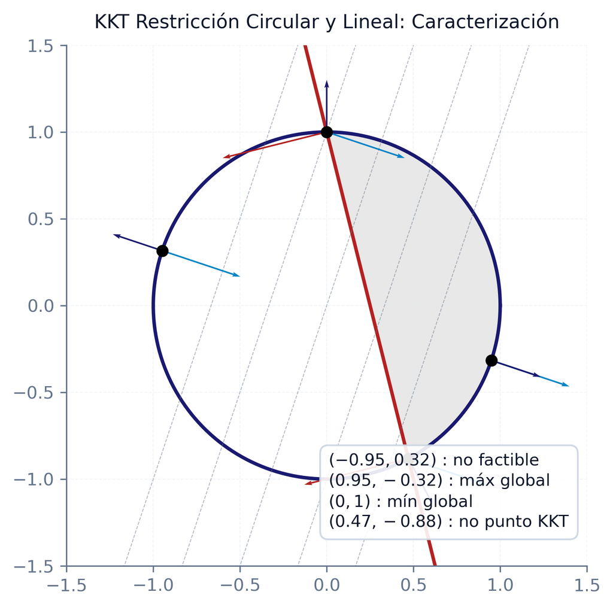

# Restricciones de igualdad y desigualdad

## Introducción a las restricciones de igualdad

- **Restricciones de igualdad**: Formulación del problema general de optimización con restricciones de igualdad $h_j(x) = 0$, para $j=1,\dots,\ell$:
  $$\min_{x} \{ f(x) \mid x \in \mathcal{X}, \ g_i(x) \le 0, \ i=1,\dots,m, \ h_j(x) = 0, \ j=1,\dots,\ell \}$$
- **Movimiento admisible**: A diferencia de las desigualdades que permiten movimientos hacia el interior de la región factible, las restricciones de igualdad obligan a que cualquier dirección admisible permanezca tangente a la hipersuperficie definida por $h_j(x) = 0$.
- **Aproximación lineal**: Localmente, el movimiento admisible debe ser ortogonal a los gradientes de las igualdades.

## Cono de direcciones tangentes para igualdades

- **Definición**: Se define el cono de direcciones tangentes al espacio de igualdad en un punto factible $\bar{x}$ como:
  $$\mathcal{H}_0(\bar{x}) = \{ d \in \mathbb{R}^n \mid \nabla h_j(\bar{x})^T d = 0, \ j = 1, \dots, \ell \}$$
- **Interpretación geométrica**: El cono tangente representa el subespacio vectorial ortogonal a los gradientes de todas las restricciones de igualdad.
- **Intersección con desigualdades**: En problemas con restricciones mixtas, una dirección factible debe pertenecer tanto al cono de restricciones de desigualdad como al cono tangente de igualdades.

## Exclusión geométrica generalizada

**Exclusión geométrica generalizada**

Sea $\bar{x}$ un mínimo local factible de $\min \{f(x) \mid g_i(x) \le 0, \ i=1,\dots,m, \ h_j(x) = 0, \ j=1,\dots,\ell\}$ e $\mathcal{I}$ el conjunto activo en $\bar{x}$. Si $f, g_i$ ($i \in \mathcal{I}$) son diferenciables en $\bar{x}$, $g_i$ ($i \notin \mathcal{I}$) son continuas en $\bar{x}$, y $h_j$ son continuamente diferenciables en $\bar{x}$ con gradientes $\nabla h_j(\bar{x})$ linealmente independientes, entonces la intersección de conos es vacía:

$$\mathcal{D}_0(\bar{x}) \cap \mathcal{G}_0(\bar{x}) \cap \mathcal{H}_0(\bar{x}) = \emptyset$$

con $\mathcal{G}_0(\bar{x}) = \{ d \mid \nabla g_i(\bar{x})^T d < 0, i \in \mathcal{I} \}$ y $\mathcal{H}_0(\bar{x}) = \{ d \mid \nabla h_j(\bar{x})^T d = 0, \forall j \}$.

## Condiciones KKT Generales (LICQ)

**Condiciones necesarias de KKT generales**

Sea $\bar{x}$ un mínimo local con conjunto activo $\mathcal{I}$ que satisface **LICQ** (los gradientes activos $\{\nabla g_i(\bar{x})\}_{i\in\mathcal{I}}$ y $\{\nabla h_j(\bar{x})\}$ son linealmente independientes). Si $f, g_i$ ($i \in \mathcal{I}$) son diferenciables en $\bar{x}$, $g_i$ ($i \notin \mathcal{I}$) son continuas en $\bar{x}$, y $h_j$ son continuamente diferenciables en $\bar{x}$, existen multiplicadores únicos $u_i \ge 0$ ($i \in \mathcal{I}$) y $v_j \in \mathbb{R}$ (sin restricción de signo) tales que:

$$\nabla f(\bar{x}) + \sum_{i \in \mathcal{I}} u_i \nabla g_i(\bar{x}) + \sum_{j=1}^\ell v_j \nabla h_j(\bar{x}) = 0$$

## Ejemplo 4: Restricciones mixtas (Planteamiento)

- **Problema de estudio**:
  $$\min \quad f(x_1, x_2)$$
  $$\text{s.a.} \quad g_1(x) = x_1^2 + x_2^2 - 5 \le 0$$
  $$g_2(x) = -x_1 \le 0, \quad g_3(x) = -x_2 \le 0$$
  $$h_1(x) = x_1 + x_2 - 3 = 0$$
- **Geometría**: El dominio factible es el segmento de recta comprendido entre los extremos **$(1,2)^T$** y **$(2,1)^T$** en el primer cuadrante.
- **Lagrangiana**:
  $$L(x, u, v) = f(x) + u_1(x_1^2 + x_2^2 - 5) - u_2 x_1 - u_3 x_2 + v_1(x_1 + x_2 - 3)$$

## Ejemplo 4: Caso A – Distancia al origen ($f_1 = x_1^2 + x_2^2$)

- **Caso A.1 (Interior del segmento, $x_1 \in (1, 2)$)**: Con $u_i = 0$, la estacionariedad requiere:
  $$2x_1 + v_1 = 0, \ 2x_2 + v_1 = 0 \implies x_1 = x_2$$
  Sustituyendo en $h_1$: $x_1 + x_2 = 3 \implies \mathbf{x}^* = (1.5, 1.5)^T, \ v_1 = -3$ (mínimo KKT, $f_1 = 4.5$).
- **Caso A.2 (Extremos del segmento)**:
  - En $(1,2)^T$ (activas $g_1, h_1$): $2 + 2u_1 + v_1 = 0, \ 4 + 4u_1 + v_1 = 0 \implies u_1 = -1 < 0$ (descartado).
  - En $(2,1)^T$ (activas $g_1, h_1$): Por simetría, $u_1 = -1 < 0$ (descartado).

## Ejemplo 4: Caso B – Distancia a $(3,2)$ ($f_2 = (x_1-3)^2 + (x_2-2)^2$)

- **Caso B.1 (Interior del segmento, $x_1 \in (1, 2)$)**: $u_i = 0$. Estacionariedad: $2(x_1-3)+v_1 = 0$, $2(x_2-2)+v_1 = 0 \implies x_1 = x_2+1$.
  $$(x_2+1)+x_2 = 3 \implies x = (2, 1)^T \quad (\text{extremo, se descarta por interior})$$
- **Caso B.2 (Extremos del segmento)**:
  - En $(1,2)^T$: $u_2=u_3=0 \implies u_1 = -2 < 0$ (descartado).
  - En $(2,1)^T$: Activa $g_1, h_1$. Estacionariedad:
    $$\left. \begin{aligned} -2 + 4u_1 + v_1 = 0 \\ -2 + 2u_1 + v_1 = 0 \end{aligned} \right\} \implies u_1 = 0 \ge 0, \ v_1 = 2$$
  - **$(2,1)^T$** es el candidato a **mínimo local** ($f_2 = 2.0$).

## Ejemplo 4: Resumen y Representación Gráfica

- **Función $f_1$ (Distancia al origen)**:
  - Mínimo KKT e interior en **$(1.5, 1.5)^T$** con $f_1 = 4.5$.
  - Los extremos de la frontera circular están descartados ($u_1 = -1 < 0$).
- **Función $f_2$ (Distancia a $(3,2)$)**:
  - No hay estacionarios interiores.
  - Mínimo KKT y global en el extremo circular **$(2, 1)^T$** con $f_2 = 2.0$ ($u_1 = 0 \ge 0$).

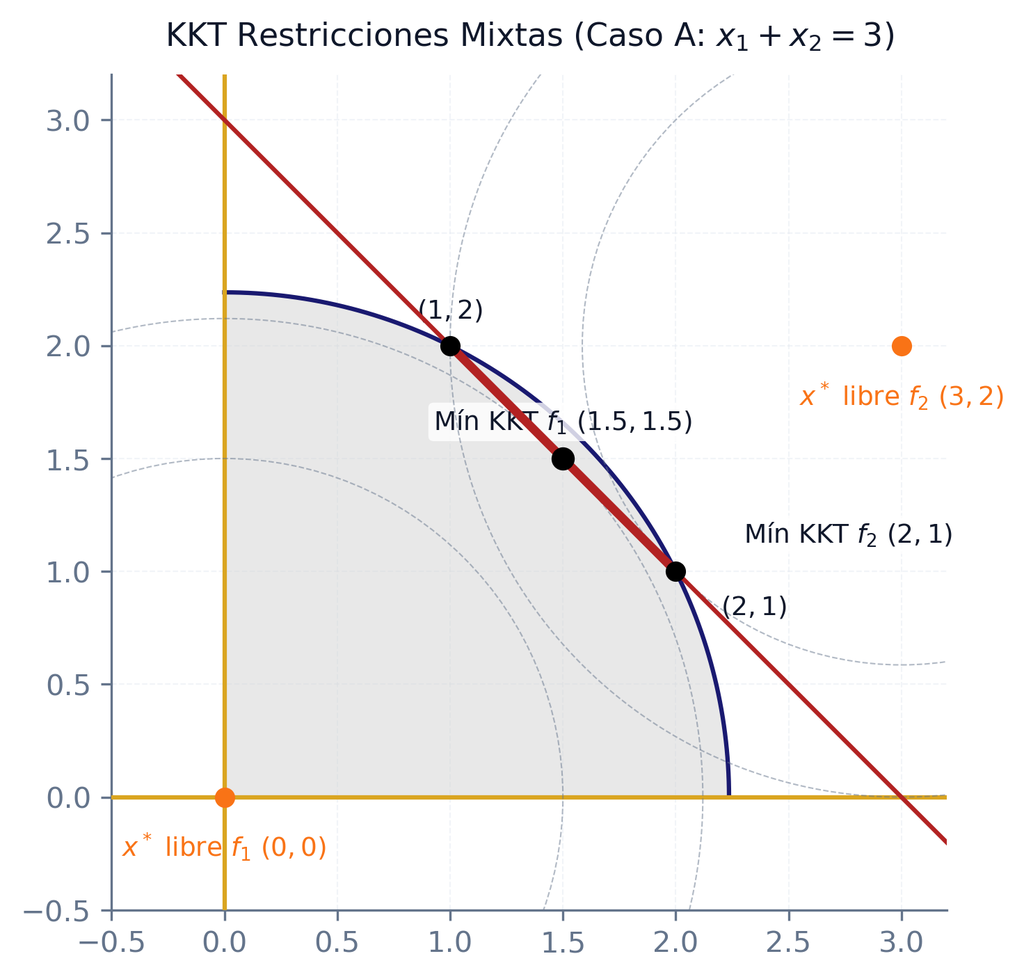

## Ejemplo 5: Modificación de frontera (Planteamiento)

- **Recta frontera asimétrica**:
  $$h_1(x) = x_1 + 2x_2 - 4 = 0$$
- **Dominio factible**: Sustituyendo $x_1 = 4-2x_2$ en la circunferencia:
  $$(4-2x_2)^2 + x_2^2 \le 5 \implies 5x_2^2 - 16x_2 + 11 \le 0 \implies x_2 \in [1, 2.2]$$
- **Primer cuadrante**: Exigiendo $x_1 \ge 0 \implies 4 - 2x_2 \ge 0 \implies x_2 \le 2$.
- **Extremos**: El segmento factible real queda delimitado por los extremos **$(2,1)^T$** y **$(0,2)^T$**.

## Ejemplo 5: Caso A – Distancia al origen ($f_1 = x_1^2 + x_2^2$)

- **Caso A.1 (Interior del segmento, $x_2 \in (1, 2)$)**: $u_i = 0$. Estacionariedad:
  $$2x_1 + v_1 = 0, \quad 2x_2 + 2v_1 = 0 \implies x_2 = 2x_1$$
  Sustituyendo en $h_1$:
  $$x_1 + 2(2x_1) = 4 \implies x^* = (0.8, 1.6)^T, \ v_1 = -1.6$$
  Satisface KKT y es el candidato a **mínimo local** ($f_1 = 3.2$).
- **Caso A.2 (Extremos del segmento)**:
  - En $(2,1)^T$: Activa $g_1, h_1 \implies u_1 = -1 < 0$ (descartado).
  - En $(0,2)^T$: Activa $g_2, h_1$ ($x_1=0$). Estacionariedad:
    $$0 - u_2 + v_1 = 0 \ \text{y} \ 4 + 2v_1 = 0 \implies v_1 = -2 \implies u_2 = -2 < 0 \quad (\text{descartado})$$

## Ejemplo 5: Caso B – Distancia a $(3,2)$ ($f_2 = (x_1-3)^2 + (x_2-2)^2$)

- **Caso B.1 (Interior del segmento, $x_2 \in (1, 2)$)**: $u_i = 0$. Estacionariedad: $2(x_1-3)+v_1 = 0$, $2(x_2-2)+2v_1 = 0 \implies x_2 = 2x_1-4$.
  $$x_1+2(2x_1-4) = 4 \implies x_1 = 2.4, \ x_2 = 0.8 < 1 \quad (\text{no factible, descartado})$$
- **Caso B.2 (Extremos del segmento)**:
  - En $(2,1)^T$: Activa $g_1, h_1$. Estacionariedad:
    $$\left. \begin{aligned} -2 + 4u_1 + v_1 = 0 \\ -2 + 2u_1 + 2v_1 = 0 \end{aligned} \right\} \implies u_1 = 1/3 \ge 0, \ v_1 = 2/3$$
    Satisface KKT y es el candidato a **mínimo local** ($f_2 = 2.0$).
  - En $(0,2)^T$: Activa $g_2, h_1 \implies u_2 = -6 < 0$ (descartado).

## Ejemplo 5: Resumen y Representación Gráfica

- **Función $f_1$ (Distancia al origen)**:
  - Mínimo KKT e interior en **$(0.8, 1.6)^T$** con $f_1 = 3.2$.
  - Los extremos de la frontera están descartados ($u_1 < 0$ y $u_2 < 0$).
- **Función $f_2$ (Distancia a $(3,2)$)**:
  - No hay estacionarios interiores factibles.
  - Mínimo KKT y global en el extremo circular **$(2, 1)^T$** con $f_2 = 2.0$ ($u_1 = 1/3 \ge 0, \ v_1 = 2/3$).

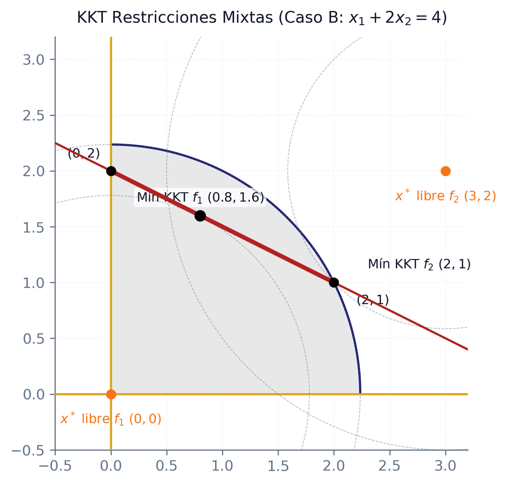